```python
#imports

import numpy as np
from scipy.integrate import solve_ivp
import matplotlib.pyplot as plt
from copy import copy as copy
```

# 1

$P' = (2P)(1-P)(1-3P)$ where P is the fraction of mice with a given mutation

## 1a.

Solve $P'=0$

$0=2P(1-P)(1-3P)$ gives us the solutions/fixed points: $P=0, 1, \frac{1}{3}$

Vector field:

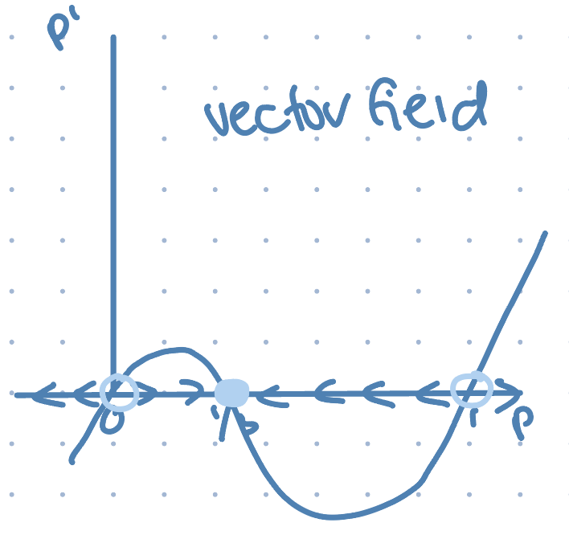

As we can see from the vector field, the fixed point $P=0$ is unstable because perturbations in the negative direction will lead to a negative $P'$ and hence will not return to 0, and pertubations in the positive direction will lead to a positive $P'$ that will ultimately settle at $P=\frac{1}{3}$ hence also not returning to 0. The fixed point $P=1$ is also unstable because perturbations in the negative direction will lead to a negative $P'$ that will ultimately settle at $P=\frac{1}{3}$ hence also not returning to 0, and pertubations in the positive direction will lead to a positive $P'$ and hence will not return to 0. The fixed point at $P=\frac{1}{3}$ is stable because perturbations in either direction will be couteracted and hence will settle back at $\frac{1}{3}$.

## 1b.

From our fixed point analysis above we know that starting at $P(0) = 0.1$ or $P(0)=0.9$ will settle at the fixed point $P=\frac{1}{3}$, since all starting values not equal to 0 or 1 will approach this stable fixed point as time approaches $\infty$. 0.9 approaches from above (P' is neg) and O.1 approaches from below (P' is pos). We can validate this by solving the ODE in python as done below:

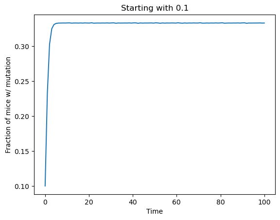

```
0.333289257104052
```

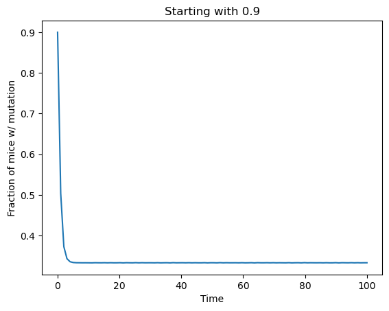

```
0.33341650837834164
```

```python
# Define the function
def ode(t, P):
    return 2*P*(1-P)*(1-3*P)

# Set P(0)
P0 = 0.1

# time span
t_span = [0, 100]

# Solve
solution = solve_ivp(ode, t_span, [P0], dense_output=True)

# Evaluate at different time points
t = np.linspace(0, 100, 100)
y = solution.sol(t_eval)

# Plot the solution
plt.plot(t, y[0])
plt.xlabel('Time')
plt.ylabel('Fraction of mice w/ mutation')
plt.title('Starting with 0.1')
plt.show()

print(y[0, 99]) # 0.33


######


# Set P(0)
P0 = 0.9

# time span
t_span = [0, 100]

# Solve
solution = solve_ivp(ode, t_span, [P0], dense_output=True)

# Evaluate at different time points
t = np.linspace(0, 100, 100)
y = solution.sol(t_eval)

# Plot the solution
plt.plot(t, y[0])
plt.xlabel('Time')
plt.ylabel('Fraction of mice w/ mutation')
plt.title('Starting with 0.9')
plt.show()

print(y[0, 99]) # 0.33
```

## 1c.

The above model is of a gene that is likely advantageous in some way since over time it will become fixed in the population, presenting in ~$\frac{1}{3}$ of the population. If for some reason at a given time point there are more or less mice in the population who are carrying the mutation (ie $0<P<1$), the fraction will still eventually even out to $\frac{1}{3}$. The only cases where this is not true are if $P=O$ or $P=1$. In these cases, the fraction will stay fixed (but unstable). To eradicate the mutation we could eliminate all mice in the population with the mutation (ie setting $P(t)= 0$) where it would remain if left unperturbed.

# 2

$T' = 24T-2T^2-3TQ$

$Q'=15Q-Q^2-3TQ$

## 2a.

$24T$ represents the growth rate of the turkey population. $-2T^2$ represents the negative feedback of intraspecies competition (more turkeys means more competition/less resources which leads to a population decrease). $-3QT$ represents the negative feedback of interspecies competition (quail and turkeys are competing for the same resources, and hence an increase in quail will cause a decrease in turkeys and visa versa).

$15Q$ represents the growth rate of the quail population. $-Q^2$ represents the negative feedback of intraspecies competition (more quail means more competition/less resources which leads to a population decrease). $-3QT$ represents the negative feedback of interspecies competition (quail and turkeys are competing for the same resources, and hence an increase in quail will cause a decrease in turkeys and visa versa).

## 2b.

We find the nullclines by setting $T'$ and $Q'$ to 0 and solving for $T$ and $Q$ respectively:

$0 = 24T-2T^2-3TQ$ solves to $T=0$ and $T=12-\frac{3}{2}Q$

$0=15Q-Q^2-3TQ$ solves to $Q=0$ and $Q=15-3T$

We then plot these in the T-Q plane where the green lines are the nullclines for T and the pink lines are the nullclines for Q:

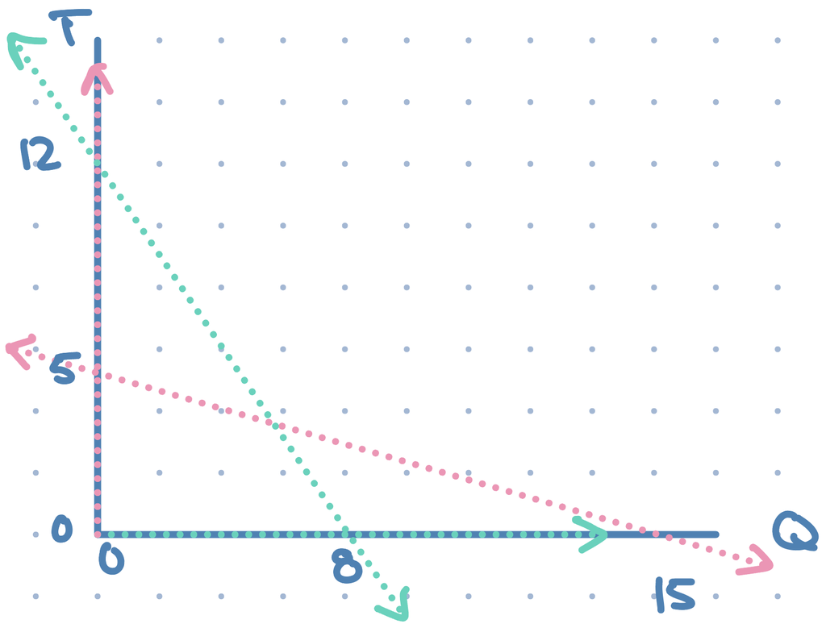

## 2c.

Using the nullclines, the equilibrium points are where the T and Q nullclines intersect. These intersections take place at (0,0), (15, 0), (0,12), and (6,3). These are the fixed points.

## 2d.

$Q=0$, solve $\dot T|_{T=0+\alpha} = \alpha(12-\alpha)$, which is positive for all $\alpha < 12$

$T=0$, solve $\dot Q|_{Q=0+\alpha} = \alpha(15-\alpha)$, which is positive for all $\alpha < 15$

$Q=0$, solve $\dot T|_{T=12+\alpha} = -2\alpha(\alpha+12)$, which is negative for all $\alpha > 0$

$T=0$, solve $\dot Q|_{Q=15+\alpha} = -\alpha(\alpha+15)$, which is negative for all $\alpha > 0$

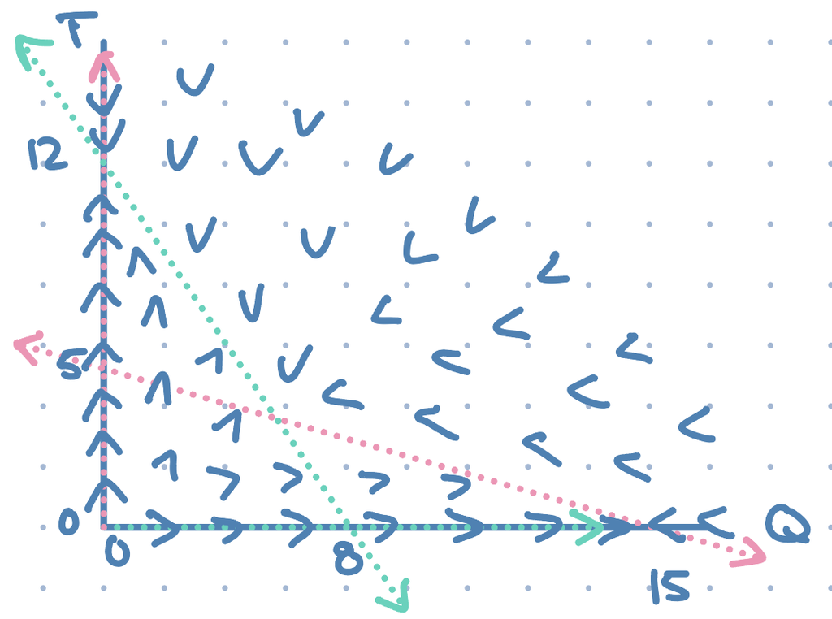

## 2e.

# 3

## 3a and 3b

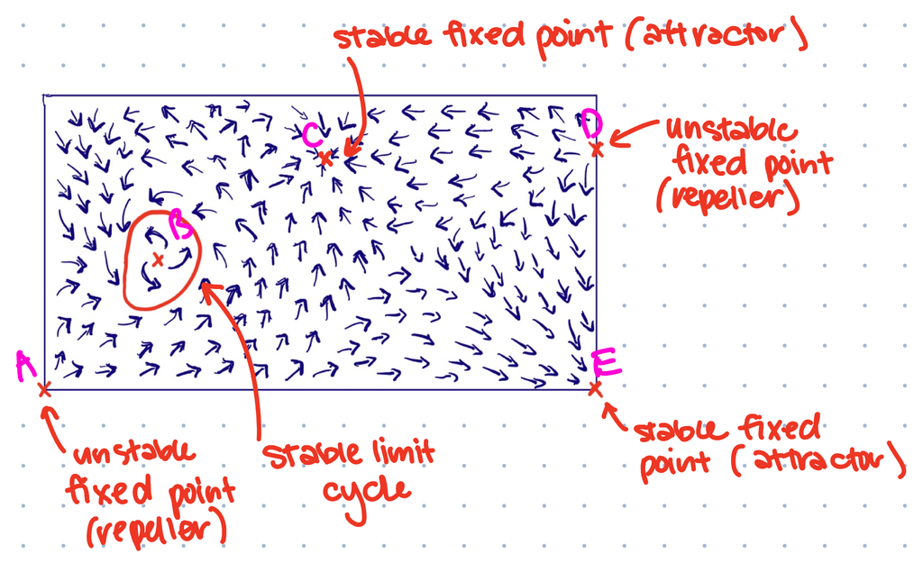

A: this is an unstable fixed point because it cannot resist pertubations. $A+\alpha$ for any $\alpha$ in the x or y direction will cause the system to leave this steady state. We can see this visually beacuse all nearby arrows are pointing away from A.

B: this is a stable limit cycle because any starting location around the cycle will fall onto the red circle. If we start inside the circle, the system will spiral outwards until it is on the cycle, if we start outside of the cycle, it will spiral inwards until it is on the cycle.

C: this is a stable fixed point (also known as an attractor) because it can resist pertubations. Any starting conditions near C will go towards C as time approaches $\infty$. We can see this visually because all nearby arrows are pointing towards C.

D: this is an unstable fixed point because is cannot resist pertubations. $A+\alpha$ for any $\alpha$ in the x or y direction will cause the system to leave this steady state. We can see this visually beacuse all nearby arrows are pointing away from D.

E: this is a stable fixed point because it can resist pertubations. Any starting conditions near E will go towards E as time approaches $\infty$. We can see this visually because all nearby arrows are pointing towards C.

# 4

## 4a

One example of oscillations in biology is the Lotka-Volterra model of predator-prey dynamics where the system oscillations betwen high predator/low prey populations and high prey/low predator populations. This is because of the feedback in this system where high predator populations cause a decrease in prey populations leading to a lack of food for predators leading to a decrease in predator populations leading to a resurgance in prey populations which leads to an abundance of food which leads to a resurgance of predator populations and so on.

Another oscillation within biology is the cycle of melatonin production in the body throughout the day. This cycle regulates the circadian rhythm/sleep-wake cycle. Melatonin production is activated by temperature among other factors, and inhibited by light and other factors. This leads to a 24-hour cycle where melatonin production peaks at night and is at its lowest during the day.

## 4b

A stable oscillatory steady state is one that resists slight pertubations and return to the same cycle. An unstable oscillatory steady state does not resist pertubations and will either converge on a point in the center or go off to infinity/become unbounded. A neutral or center oscillatory steady state, if perturbed, will change, but it will ultimately settle into a new cycle.

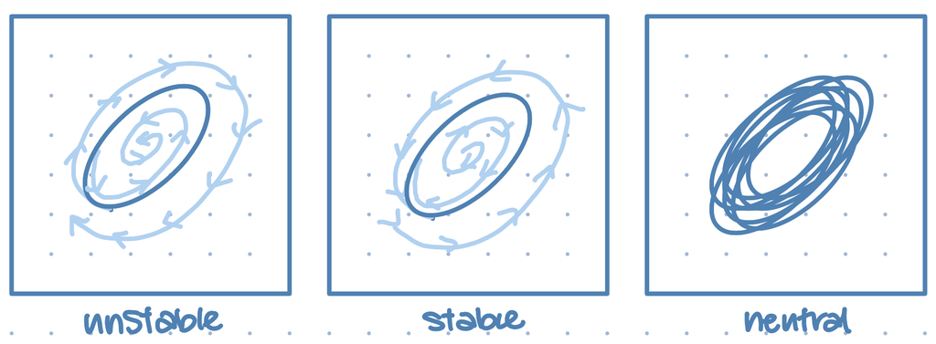

# 5

Chaos is a dynamical behavior that is deterministic and bounded in the state space, but irregular and extremely sensitive to initial conditions. This means that the system is not noisy, it does not go to infinity, it does not repeat in its behavior, and even slight differences in starting behavior can cause wholly different/uncorrelated dynamics. This means that if you start the system with the same starting conditions, you will get the same steady state/result dynamics, but if you start it with even a slightly different conditions, you will see wholly different results.

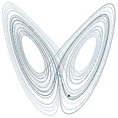

This is the Lorenze model (because I don't trust my drawing skills to create loops that look this good). It appears as an intricite pattern of loops that fill the phase plane in a bounded manner. As we can see, the model is deterministic but unpredictable given different initial conditions, since each initial condition will lead to completely different behavior that is seeminly completely random.

# 6

$\frac{dx_i}{dt}=\beta x_j \frac{1}{1+x_j^n}-\gamma x_i$ where there are three possible pairs of $(i, j): (1,3), (2,1), (3, 2)$

## 6a

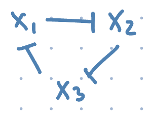

## 6b

We would model this with a master equation (ie Guiseppe's method) if we wanted fully stochastic descriptions of a discrete population and the model was "simple enough". This works particularly well when there are small populations of cells.

## 6c

We would use an SDE model if we need to incorporate noise into the model and/or if the interactions in the model are complex. In this model, we would use an SDE if there are a large number of moleules but many stochastic fluctuations.

## 6d

$\frac{dX_i}{dX_t}=\beta x_j \frac{1}{1+x_j^n}-\gamma x_i + cX_i \times \frac{dw_t}{dX_t}$

$\beta x_j \frac{1}{1+x_j^n}-\gamma x_i$: the normal deterministic model/interaction model $cX_i$: multiplicative noise, meaning that the noise is proportional to the population size by a factor of $c$ $\frac{dw_t}{dX_t}$: Brownian motion

# 7

$\frac{dx}{dt} = \frac{a+x^2}{1+x^2}-rx$ where the parameters $a, r$ determine the system dynamics.

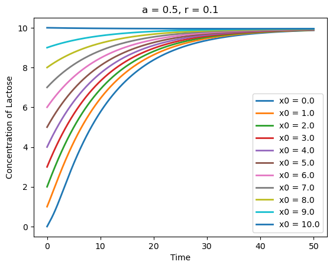

```
[9.95035532]
```

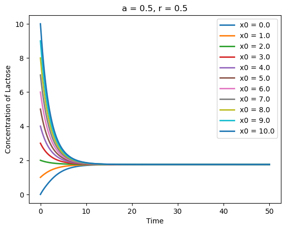

```
[1.75487768]
```

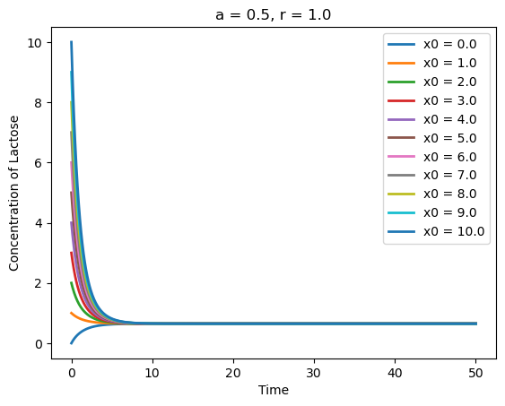

```
[0.64779887]
```

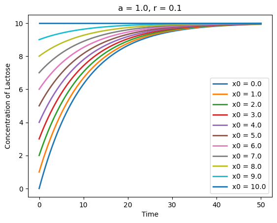

```
[10.]
```

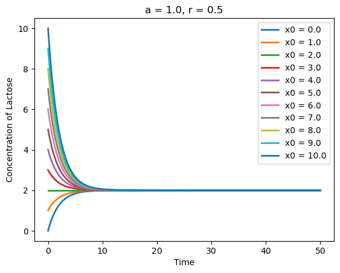

```
[2.]
```

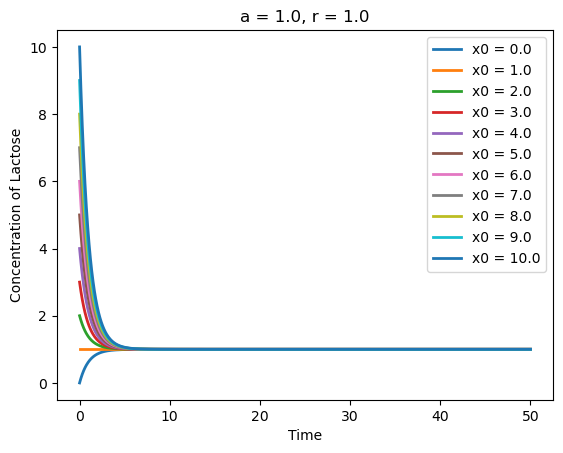

```
[1.]
```

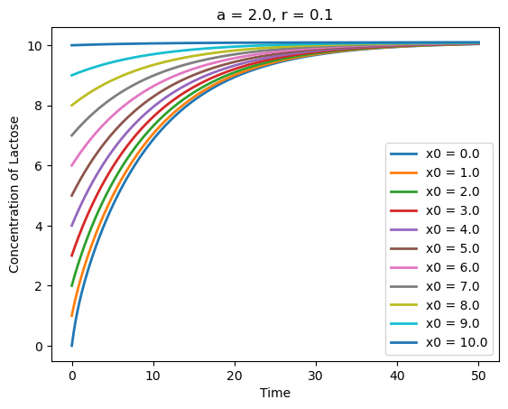

```
[10.09653769]
```

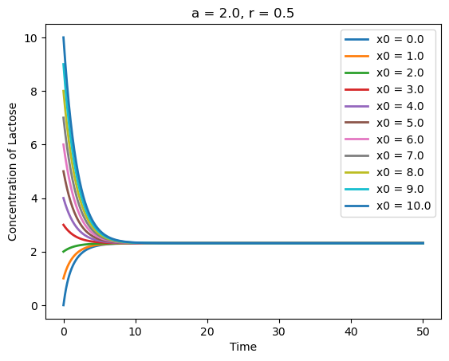

```
[2.31459621]
```

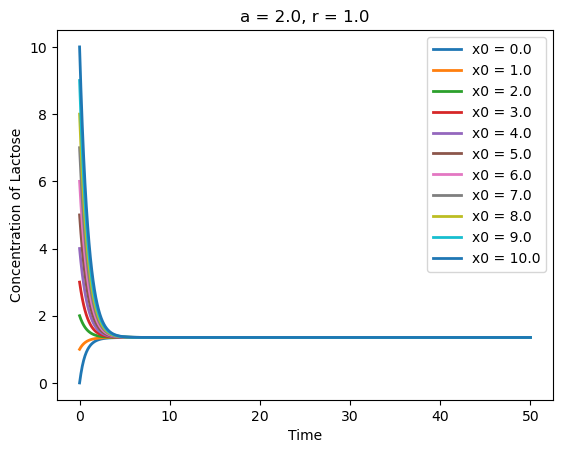

```
[1.35320996]
```

```python
def ode(x, t, a, r):
    dxdt = (a + x**2)/(1 + x**2) - r*x
    return dxdt

# Define params
a_values = [0.5, 1.0, 2.0]
r_values = [0.1, 0.5, 1.0]
t = np.linspace(0, 50, 1000)

# Set initial conditions
x0 = np.linspace(0, 10, 11)

# Loop over params and plot
for a in a_values:
    for r in r_values:
        fig, ax = plt.subplots()
        ax.set_title(f'a = {a}, r = {r}')
        ax.set_xlabel('Time')
        ax.set_ylabel('Concentration of Lactose')

        for x_init in x0:
            x = odeint(lac_operon, x_init, t, args=(a, r))

            ax.plot(t, x, '-', lw=2, label=f'x0 = {x_init:.1f}')

        ax.legend()
        plt.show()

        print(x[999]) # equil value
```

Depending on the chosen $a$ and $r$ parameters, the equilibrium values of the system will change. It seems that, holding $a$ constant, when we increase the $r$ parameter, the equilibrium also decreases. It seems like, holding $r$ constant, as we increase $a$, the concentration also increases, though the affect is very slight.

## 7b

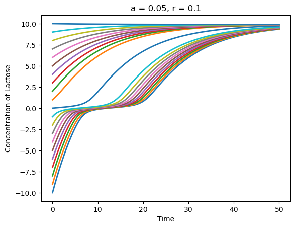

```
[9.94152748]
```

```python
a = 0.05
r = 0.1
t = np.linspace(0, 50, 100)

# Set initial conditions
x0 = np.linspace(-10, 10, 21) # simulating with negative initial conditions for sake of model (not possible biologically)

# Loop over params and plot
fig, ax = plt.subplots()
ax.set_title(f'a = {a}, r = {r}')
ax.set_xlabel('Time')
ax.set_ylabel('Concentration of Lactose')

for x_init in x0:
    x = odeint(lac_operon, x_init, t, args=(a, r))

    ax.plot(t, x, '-', lw=2, label=f'x0 = {x_init:.1f}')

plt.show()

print(x[19])
```

With $a = 0.05$ and $r=0.1$, we can see that there are indeed two steady states. There is a steady state at 9.94 which appears to be the ultimately equilibrium value, and there is a steady state at 0. This second steady state is unstable as the populations do not stay at this concentration for long.

## 7c

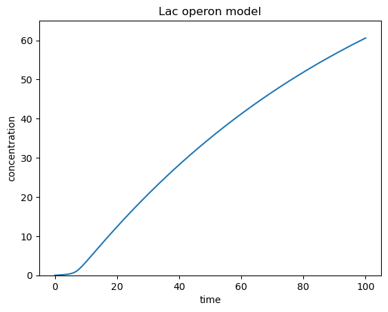

```python
## Bifurcation analysis

# we must give a name
DSargs = dst.args(name='Lac operon model')

# parameters
DSargs.pars = { 'a': 0.05,
               'r': 0.01} ## change?

# rhs of the differential equation
DSargs.varspecs = {'x': '(a+x**2)/(1+x**2)-r*x'}
# initial conditions
DSargs.ics      = {'x': 0}

DSargs.tdomain = [0,100]                         # set the range of integration.
ode  = dst.Generator.Vode_ODEsystem(DSargs)     # an instance of the 'Generator' class.
traj = ode.compute('polarization')              # integrate ODE
pts  = traj.sample(dt=0.1)                      # Data for plotting

# PyPlot commands
plt.plot(pts['t'], pts['x'])
plt.xlabel('time')                              # Axes labels
plt.ylabel('concentration')                           # ...
plt.ylim([0,65])                                # Range of the y axis
plt.title(ode.name)                             # Figure title from model name
plt.show()
```

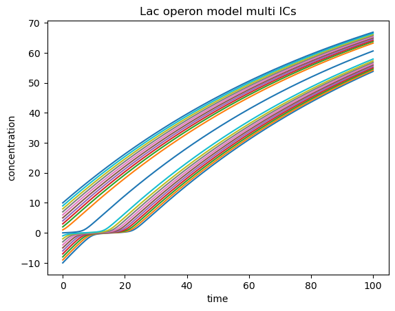

```python
for r, x0 in enumerate(np.linspace(-10,10,21)):
    ode.set( ics = { 'x': x0 } )                # Initial condition
    # Trajectories are called pol0, pol1, ...
    # sample them on the fly to create Pointset tmp
    tmp = ode.compute('pol%3i' % i).sample()    # or specify dt option to sample to sub-sample
    plt.plot(tmp['t'], tmp['x'])
plt.xlabel('time')
plt.ylabel('concentration')
plt.title(ode.name + ' multi ICs')
plt.show()
```

```python
# Prepare the system to start close to a steady state
ode.set(pars = {'r': -1} )       # Lower bound of the control parameter 'i'
ode.set(ics =  {'x': -20} )       # Close to one of the steady states present for i=-220

PC = dst.ContClass(ode)            # Set up continuation class

PCargs = dst.args(name='EQ1', type='EP-C')     # 'EP-C' stands for Equilibrium Point Curve. The branch will be labeled 'EQ1'.
PCargs.freepars     = ['r']                    # control parameter(s) (it should be among those specified in DSargs.pars)
PCargs.MaxNumPoints = 450                      # The following 3 parameters are set after trial-and-error
PCargs.MaxStepSize  = 2
PCargs.MinStepSize  = 1e-5
PCargs.StepSize     = 2e-2
PCargs.LocBifPoints = 'LP'                     # detect limit points / saddle-node bifurcations
PCargs.SaveEigen    = True                     # to tell unstable from stable branches
```

[output not shown]

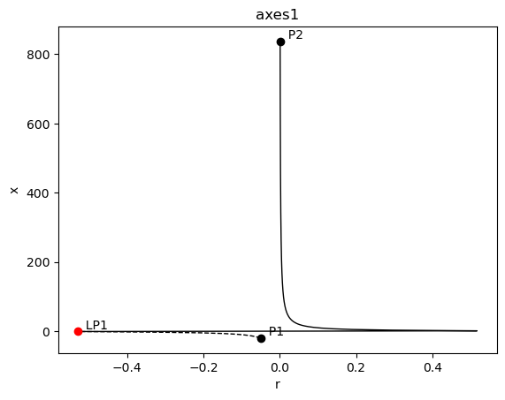

```python
PC.newCurve(PCargs)
PC['EQ1'].forward()
PC.display(['r','x'], stability=True, figure=3)
```

The model is bistable from LP1 to P1 (approximately -0.6 to -0.05).

## 7d

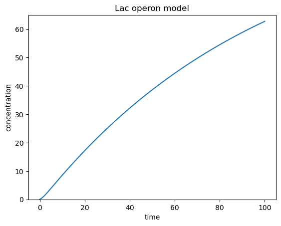

```python
## Bifurcation analysis

# we must give a name
DSargs = dst.args(name='Lac operon model')

# parameters
DSargs.pars = { 'a': 0.5,
               'r': 0.01} ## change?

# rhs of the differential equation
DSargs.varspecs = {'x': '(a+x**2)/(1+x**2)-r*x'}
# initial conditions
DSargs.ics      = {'x': 0}

DSargs.tdomain = [0,100]                         # set the range of integration.
ode  = dst.Generator.Vode_ODEsystem(DSargs)     # an instance of the 'Generator' class.
traj = ode.compute('polarization')              # integrate ODE
pts  = traj.sample(dt=0.1)                      # Data for plotting

# PyPlot commands
plt.plot(pts['t'], pts['x'])
plt.xlabel('time')                              # Axes labels
plt.ylabel('concentration')                           # ...
plt.ylim([0,65])                                # Range of the y axis
plt.title(ode.name)                             # Figure title from model name
plt.show()
```

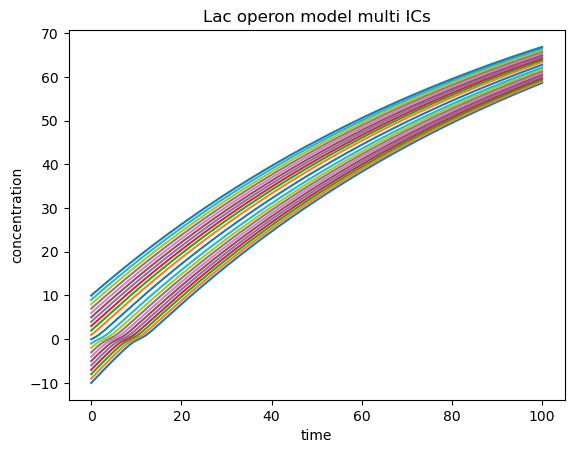

```python
for r, x0 in enumerate(np.linspace(-10,10,21)):
    ode.set( ics = { 'x': x0 } )                # Initial condition
    # Trajectories are called pol0, pol1, ...
    # sample them on the fly to create Pointset tmp
    tmp = ode.compute('pol%3i' % i).sample()    # or specify dt option to sample to sub-sample
    plt.plot(tmp['t'], tmp['x'])
plt.xlabel('time')
plt.ylabel('concentration')
plt.title(ode.name + ' multi ICs')
plt.show()
```

```python
# Prepare the system to start close to a steady state
ode.set(pars = {'r': 10} )       # Lower bound of the control parameter 'i'
ode.set(ics =  {'x': -100} )       # Close to one of the steady states present for i=-220

PC = dst.ContClass(ode)            # Set up continuation class

PCargs = dst.args(name='EQ1', type='EP-C')     # 'EP-C' stands for Equilibrium Point Curve. The branch will be labeled 'EQ1'.
PCargs.freepars     = ['r']                    # control parameter(s) (it should be among those specified in DSargs.pars)
PCargs.MaxNumPoints = 450                      # The following 3 parameters are set after trial-and-error
PCargs.MaxStepSize  = 2
PCargs.MinStepSize  = 1e-4
PCargs.StepSize     = 2e-2
PCargs.LocBifPoints = 'LP'                     # detect limit points / saddle-node bifurcations
PCargs.SaveEigen    = True                     # to tell unstable from stable branches
```

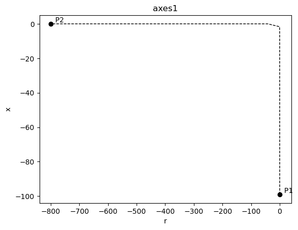

```python
PC.newCurve(PCargs)
PC['EQ1'].forward()
PC.display(['r','x'], stability=True, figure=3)
```

It appears as if there are no saddle points because there are no locations where the stability changes. Numerically, increasing $a$ to 0.5 increases the rate of change of $x$, however I do not understand why this would lead to the loss of our saddle point :(